# IODS course project

Milla Peltoniemi

# About the project

1. Tools and methods for open and reproducible research R, RStudio, Rmarkdown, GitHub
2. Regression and model validation
3. Logistic regression
4. Clustering and classification, Discriminant analysis (DA), K-means clustering (KMC)
5. Dimensionality reduction techniques, Principal component analysis (PCA), Multiple Correspondence analysis (MCA)

https://github.com/nimirum/IODS-project

# Week 2: Regression and Model Validation

This week’s topic was about linear regression and its extended form, the multiple linear regression.

I installed ggplot2 and GGally for data anylsis. I read the students2014 data into R.

```r
library(ggplot2)
library(GGally)
lrn14 <- read.csv('data/learning2014.txt',sep=',')
```

The data is [a study](http://www.helsinki.fi/~kvehkala/JYTmooc/JYTOPKYS2-meta.txt) from a course “Johdatus yhteiskuntatilastotieteeseen, syksy 2014” about learning and teaching statistics. It has 7 different variables

1. Age (in years) derived from the date of birth
2. Gender: Male = 1 or Female = 2
3. Attitude is a global attitude towards statistics
4. Deep is an combination of feelings with statisics
5. Stra is an combination of learning strategics
6. Surf is an combination of which things to concentrate on studies
7. Points is total points (max of all)

Data structure and first 5 rows of it.

```r
dim(lrn14)
```

```
## [1] 166   7
```

```r
str(lrn14)
```

```
## 'data.frame':    166 obs. of  7 variables:
##  $ gender  : Factor w/ 2 levels "F","M": 1 2 1 2 2 1 2 1 2 1 ...
##  $ age     : int  53 55 49 53 49 38 50 37 37 42 ...
##  $ attitude: num  3.7 3.1 2.5 3.5 3.7 3.8 3.5 2.9 3.8 2.1 ...
##  $ deep    : num  3.58 2.92 3.5 3.5 3.67 ...
##  $ stra    : num  3.38 2.75 3.62 3.12 3.62 ...
##  $ surf    : num  2.58 3.17 2.25 2.25 2.83 ...
##  $ points  : int  25 12 24 10 22 21 21 31 24 26 ...
```

```r
head(lrn14, n=5)
```

```
##   gender age attitude     deep  stra     surf points
## 1      F  53      3.7 3.583333 3.375 2.583333     25
## 2      M  55      3.1 2.916667 2.750 3.166667     12
## 3      F  49      2.5 3.500000 3.625 2.250000     24
## 4      M  53      3.5 3.500000 3.125 2.250000     10
## 5      M  49      3.7 3.666667 3.625 2.833333     22
```

A graphical overview of the data

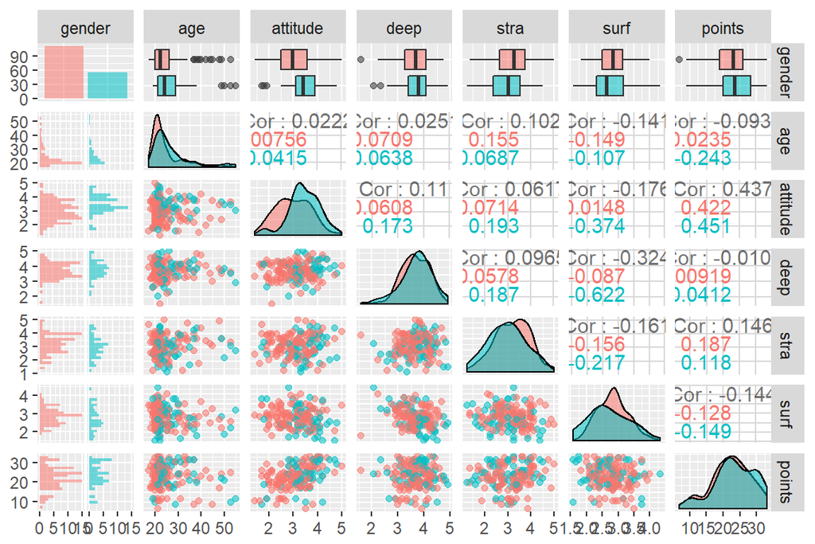

```r
ggpairs(lrn14, mapping = aes(col=gender, alpha=0.3), lower = list(combo = wrap("facethist", bins = 20)))
```

There seems to be correlation with points and attitude. Stra and deep values seems to have some shape of normal distribution. The surveys participants are mostly close to age 20 and total points are fairly evenly distributed.

I choose three variables (attitude, stra, surf) as explanatory variables to fit a regression model where exam points is the target (dependent) variable.

```r
model <- lm(points ~ attitude + stra + surf, data = lrn14)
summary(model)
```

```
##
## Call:
## lm(formula = points ~ attitude + stra + surf, data = lrn14)
##
## Residuals:
##      Min       1Q   Median       3Q      Max
## -17.1550  -3.4346   0.5156   3.6401  10.8952
##
## Coefficients:
##             Estimate Std. Error t value Pr(>|t|)
## (Intercept)  11.0171     3.6837   2.991  0.00322 **
## attitude      3.3952     0.5741   5.913 1.93e-08 ***
## stra          0.8531     0.5416   1.575  0.11716
## surf         -0.5861     0.8014  -0.731  0.46563
## ---
## Signif. codes:  0 '***' 0.001 '**' 0.01 '*' 0.05 '.' 0.1 ' ' 1
##
## Residual standard error: 5.296 on 162 degrees of freedom
## Multiple R-squared:  0.2074, Adjusted R-squared:  0.1927
## F-statistic: 14.13 on 3 and 162 DF,  p-value: 3.156e-08
```

Only attitude seems to correlate (***) with points so I removed stra and surf

```r
model <- lm(points ~ attitude, data = lrn14)
summary(model)
```

```
##
## Call:
## lm(formula = points ~ attitude, data = lrn14)
##
## Residuals:
##      Min       1Q   Median       3Q      Max
## -16.9763  -3.2119   0.4339   4.1534  10.6645
##
## Coefficients:
##             Estimate Std. Error t value Pr(>|t|)
## (Intercept)  11.6372     1.8303   6.358 1.95e-09 ***
## attitude      3.5255     0.5674   6.214 4.12e-09 ***
## ---
## Signif. codes:  0 '***' 0.001 '**' 0.01 '*' 0.05 '.' 0.1 ' ' 1
##
## Residual standard error: 5.32 on 164 degrees of freedom
## Multiple R-squared:  0.1906, Adjusted R-squared:  0.1856
## F-statistic: 38.61 on 1 and 164 DF,  p-value: 4.119e-09
```

Multiple R-squared of the model is approxrimately 0,19. The best value is 1, therefore the model explains 19% of the exam points is due to attitude.

Diagnostic plots: Residuals vs Fitted values, Normal QQ-plot and Residuals vs Leverage.

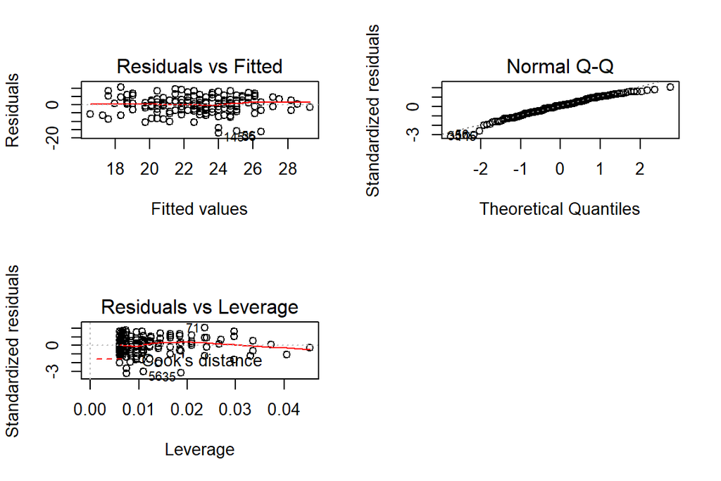

```r
par(mfrow = c(2,2))
plot(model, which = c(1,2,5))
```

It seems that the only plot that fits the data is Normal QQ.

# Week 3: Logistic regresion

This week’s topic was about logistic regression

### The data

I read the students performance and alcoholic consumption data into R.

```r
library(tidyr); library(dplyr); library(ggplot2); library(boot)
alc <- read.csv('data/students_alc2014.csv',sep=',')
```

[The data set](https://archive.ics.uci.edu/ml/datasets/Student+Performance) is from UCI Machine Learning Repository, Student Performance Data Set and it contains students performance in mathematics and portuguese, including alcohol consumption. The acl data is a joined data frame from mathematics and portuguese data. The data set has meen modified so that the ‘alc_use’ is the average of ‘Dalc’ and ‘Walc’. The variable ‘high_use’ is TRUE if ‘alc_use’ is higher than 2 and FALSE otherwise.

Glimpse of data and first 5 rows of it.

```r
glimpse(alc)
```

```
## Observations: 382
## Variables: 35
## $ school     <fctr> GP, GP, GP, GP, GP, GP, GP, GP, GP, GP, GP, GP, GP...
## $ sex        <fctr> F, F, F, F, F, M, M, F, M, M, F, F, M, M, M, F, F,...
## $ age        <int> 18, 17, 15, 15, 16, 16, 16, 17, 15, 15, 15, 15, 15,...
## $ address    <fctr> U, U, U, U, U, U, U, U, U, U, U, U, U, U, U, U, U,...
## $ famsize    <fctr> GT3, GT3, LE3, GT3, GT3, LE3, LE3, GT3, LE3, GT3, ...
## $ Pstatus    <fctr> A, T, T, T, T, T, T, A, A, T, T, T, T, T, A, T, T,...
## $ Medu       <int> 4, 1, 1, 4, 3, 4, 2, 4, 3, 3, 4, 2, 4, 4, 2, 4, 4, ...
## $ Fedu       <int> 4, 1, 1, 2, 3, 3, 2, 4, 2, 4, 4, 1, 4, 3, 2, 4, 4, ...
## $ Mjob       <fctr> at_home, at_home, at_home, health, other, services...
## $ Fjob       <fctr> teacher, other, other, services, other, other, oth...
## $ reason     <fctr> course, course, other, home, home, reputation, hom...
## $ nursery    <fctr> yes, no, yes, yes, yes, yes, yes, yes, yes, yes, y...
## $ internet   <fctr> no, yes, yes, yes, no, yes, yes, no, yes, yes, yes...
```

[output cut: 22 more lines]

```r
head(alc, n=5)
```

```
##   school sex age address famsize Pstatus Medu Fedu    Mjob     Fjob reason
## 1     GP   F  18       U     GT3       A    4    4 at_home  teacher course
## 2     GP   F  17       U     GT3       T    1    1 at_home    other course
## 3     GP   F  15       U     LE3       T    1    1 at_home    other  other
## 4     GP   F  15       U     GT3       T    4    2  health services   home
## 5     GP   F  16       U     GT3       T    3    3   other    other   home
##   nursery internet guardian traveltime studytime failures schoolsup famsup
## 1     yes       no   mother          2         2        0       yes     no
## 2      no      yes   father          1         2        0        no    yes
## 3     yes      yes   mother          1         2        2       yes     no
## 4     yes      yes   mother          1         3        0        no    yes
## 5     yes       no   father          1         2        0        no    yes
##   paid activities higher romantic famrel freetime goout Dalc Walc health
## 1   no         no    yes       no      4        3     4    1    1      3
## 2   no         no    yes       no      5        3     3    1    1      3
## 3  yes         no    yes       no      4        3     2    2    3      3
## 4  yes        yes    yes      yes      3        2     2    1    1      5
## 5  yes         no    yes       no      4        3     2    1    2      5
##   absences G1 G2 G3 alc_use high_use
## 1        5  2  8  8     1.0    FALSE
## 2        3  7  8  8     1.0    FALSE
## 3        8 10 10 11     2.5     TRUE
## 4        1 14 14 14     1.0    FALSE
## 5        2  8 12 12     1.5    FALSE
```

### Hypothesis testing

I choose 4 variables and present a hypothesis on how they correlate with high/low alchohol consumption. The variables are failure, sex, activities and absences from school. Below are my hypothesis:

H1: High alcohol consumption realtes to the amount of course failures.

H2: Sex indicates alcohol consumption.

H3: More time spent on activities implies less alcohol consupmtion

H4: High amount of absences relates to high alcohol consumption.

Below is the data structure.

```r
variables <- c("high_use","failures","activities","sex","absences")
alc_hyp_test <- select(alc, one_of(variables))
glimpse(alc_hyp_test)
```

```
## Observations: 382
## Variables: 5
## $ high_use   <lgl> FALSE, FALSE, TRUE, FALSE, FALSE, FALSE, FALSE, FAL...
## $ failures   <int> 0, 0, 2, 0, 0, 0, 0, 0, 0, 0, 0, 0, 0, 0, 0, 0, 0, ...
## $ activities <fctr> no, no, no, yes, no, yes, no, no, no, yes, no, yes...
## $ sex        <fctr> F, F, F, F, F, M, M, F, M, M, F, F, M, M, M, F, F,...
## $ absences   <int> 5, 3, 8, 1, 2, 8, 0, 4, 0, 0, 1, 2, 1, 1, 0, 5, 8, ...
```

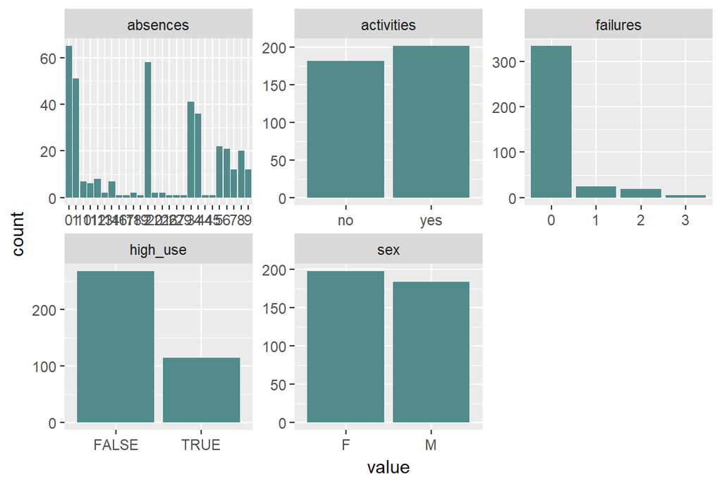

```r
gather(alc_hyp_test) %>% ggplot(aes(value)) + facet_wrap("key", scales = "free") + geom_bar(fill="darkslategray4")
```

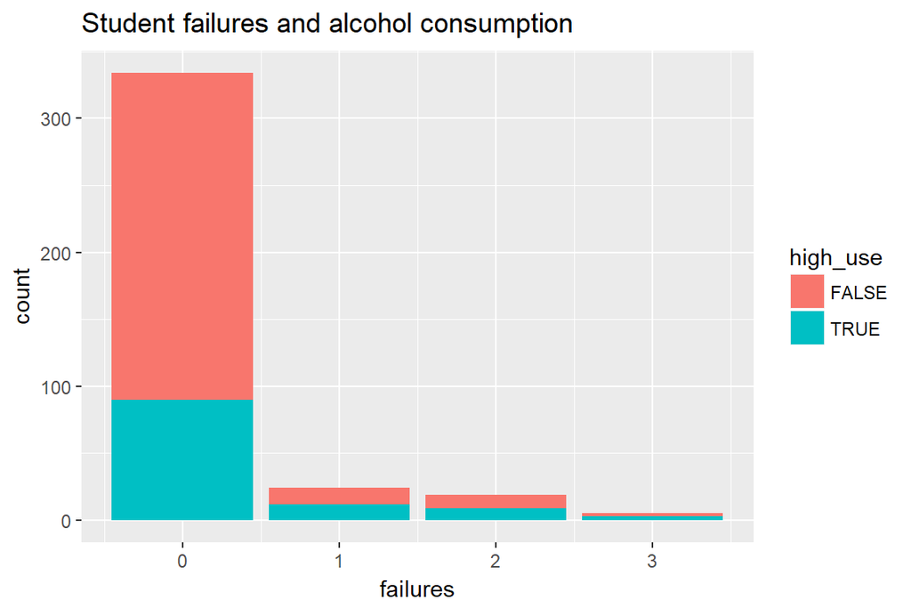

```r
g1 <- ggplot(alc, aes(x = failures, fill=high_use))
g1 + geom_bar() + ggtitle("Student failures and alcohol consumption")
```

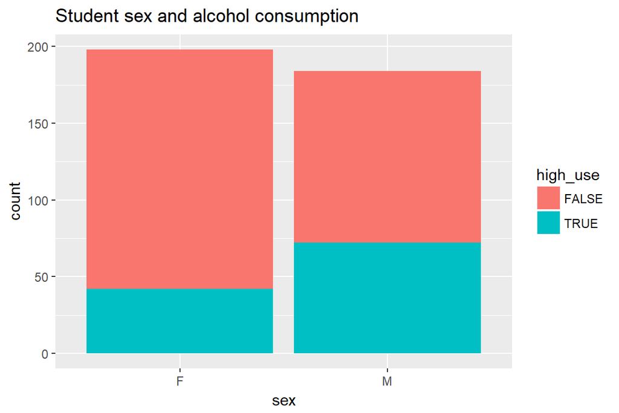

```r
g2 <- ggplot(alc, aes(x = sex, fill=high_use))
g2 + geom_bar() + ggtitle("Student sex and alcohol consumption")
```

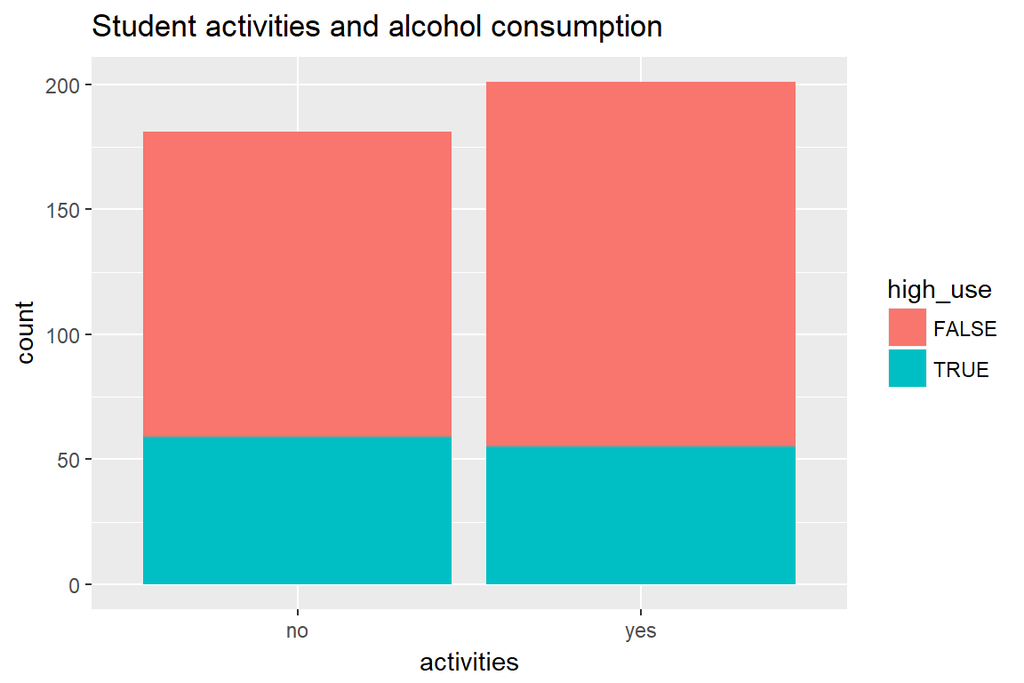

```r
g3 <- ggplot(alc, aes(x = activities, fill=high_use))
g3 + geom_bar() + ggtitle("Student activities and alcohol consumption")
```

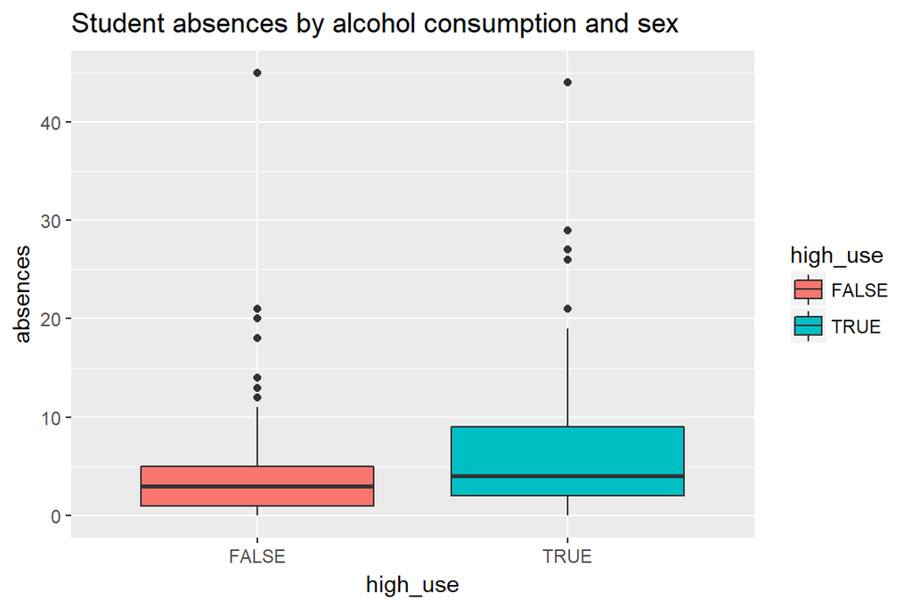

```r
g4 <- ggplot(alc, aes(x = high_use, y = absences, fill=high_use))
g4 + geom_boxplot() + ylab("absences") + ggtitle("Student absences by alcohol consumption and sex")
```

About 1/3 of students are categorized as high alcohol consumption users. In first chart (g1) it is hard to say if high alchohol use affect failures or not. The second chart (g2) indicates that males consumpt more alcohol than women. In the third chart (g3) seems that activities implies less achohol use, but not that much. In the last chart (g4) it looks like absences are related to high alchohol consumption.

### Logistic regression

```r
model <- glm(high_use ~ failures + sex + absences + activities -1, data = alc_hyp_test, family = "binomial")

summary(model)
```

```
##
## Call:
## glm(formula = high_use ~ failures + sex + absences + activities -
##     1, family = "binomial", data = alc_hyp_test)
##
## Deviance Residuals:
##     Min       1Q   Median       3Q      Max
## -2.2605  -0.8527  -0.5999   1.0786   2.1020
##
## Coefficients:
##               Estimate Std. Error z value Pr(>|z|)
## failures       0.43063    0.19104   2.254  0.02419 *
## sexF          -1.74791    0.24779  -7.054 1.74e-12 ***
## sexM          -0.76106    0.23390  -3.254  0.00114 **
## absences       0.09382    0.02295   4.089 4.33e-05 ***
## activitiesyes -0.34489    0.24071  -1.433  0.15191
## ---
## Signif. codes:  0 '***' 0.001 '**' 0.01 '*' 0.05 '.' 0.1 ' ' 1
##
## (Dispersion parameter for binomial family taken to be 1)
##
##     Null deviance: 529.56  on 382  degrees of freedom
## Residual deviance: 422.34  on 377  degrees of freedom
## AIC: 432.34
##
## Number of Fisher Scoring iterations: 4
```

The students high alchohol use seems to relate most with sex and amount of absences because the coefficents are ***. I drop activities and reproduce logistic regression without it.

```r
model <- glm(high_use ~ failures + sex + absences, data = alc_hyp_test, family = "binomial")

summary(model)
```

```
##
## Call:
## glm(formula = high_use ~ failures + sex + absences, family = "binomial",
##     data = alc_hyp_test)
##
## Deviance Residuals:
##     Min       1Q   Median       3Q      Max
## -2.1855  -0.8371  -0.6000   1.1020   2.0209
##
## Coefficients:
##             Estimate Std. Error z value Pr(>|z|)
## (Intercept) -1.90297    0.22626  -8.411  < 2e-16 ***
## failures     0.45082    0.18992   2.374 0.017611 *
## sexM         0.94117    0.24200   3.889 0.000101 ***
## absences     0.09322    0.02295   4.063 4.85e-05 ***
## ---
## Signif. codes:  0 '***' 0.001 '**' 0.01 '*' 0.05 '.' 0.1 ' ' 1
##
## (Dispersion parameter for binomial family taken to be 1)
##
##     Null deviance: 465.68  on 381  degrees of freedom
## Residual deviance: 424.40  on 378  degrees of freedom
## AIC: 432.4
##
## Number of Fisher Scoring iterations: 4
```

```r
OR <- coef(model) %>% exp
CI <- confint(model) %>% exp
cbind(OR, CI)
```

```
##                    OR      2.5 %   97.5 %
## (Intercept) 0.1491257 0.09395441 0.228611
## failures    1.5695984 1.08339644 2.294737
## sexM        2.5629682 1.60381392 4.149405
## absences    1.0977032 1.05169654 1.150848
```

In here we can see that people with alcohol use are more likely to have high course failure count high chance of having absences. In odds ratio model the high alcohol students are more probably males than females. These results support my hypothesis.

### Prediction

```r
probabilities <- predict(model, type = "response")

alc_hyp_test <- mutate(alc_hyp_test, probability = probabilities)
alc_hyp_test <- mutate(alc_hyp_test, prediction = probabilities > 0.5)
table(high_use = alc_hyp_test$high_use, prediction = probabilities > 0.5)
```

```
##         prediction
## high_use FALSE TRUE
##    FALSE   259    9
##    TRUE     84   30
```

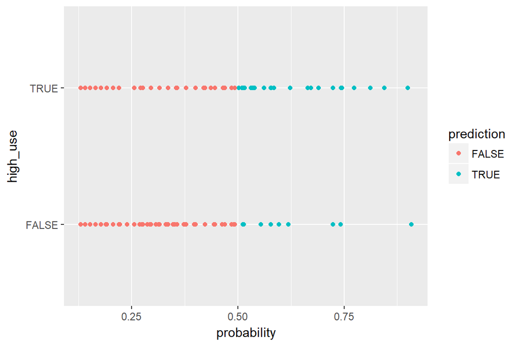

```r
g <- ggplot(alc_hyp_test, aes(x = probability, y = high_use, col= prediction))
g + geom_point()
```

```r
table(high_use = alc_hyp_test$high_use, prediction = alc_hyp_test$prediction) %>% prop.table()  %>% addmargins()
```

```
##         prediction
## high_use      FALSE       TRUE        Sum
##    FALSE 0.67801047 0.02356021 0.70157068
##    TRUE  0.21989529 0.07853403 0.29842932
##    Sum   0.89790576 0.10209424 1.00000000
```

```r
loss_func <- function(class, prob) {
  n_wrong <- abs(class - prob) > 0.5
  mean(n_wrong)
}

loss_func(class = alc_hyp_test$high_use, prob = alc_hyp_test$probability)
```

```
## [1] 0.2434555
```

The prediction model predicts about 24% of the predictions wrong.

### Cross validation

```r
cv <- cv.glm(data = alc_hyp_test, cost = loss_func, glmfit = model, K = 10)

cv$delta[1]
```

```
## [1] 0.2591623
```

Cross validation (k=10) seems to add the amount of wrong predictions